# CASE STUDY 1

```python
import pandas as pd
import numpy as np
import matplotlib.pyplot as plt
import seaborn as sns
```

```python
df=pd.read_csv('loan_1.csv')
df.head()
```

|  | emp_title | emp_length | state | homeownership | annual_income | verified_income | debt_to_income | annual_income_joint | verification_income_joint | debt_to_income_joint | ... | issue_month | loan_status | initial_listing_status | disbursement_method | balance | paid_total | paid_principal | paid_interest | paid_late_fees | Unnamed: 55 |
| --- | --- | --- | --- | --- | --- | --- | --- | --- | --- | --- | --- | --- | --- | --- | --- | --- | --- | --- | --- | --- | --- |
| 0 | global config engineer | 3.0 | NJ | MORTGAGE | 90000.0 | Verified | 18.01 | NaN | NaN | NaN | ... | Mar-2018 | Current | whole | Cash | 27015.86 | 1999.33 | 984.14 | 1015.19 | 0.0 | NaN |
| 1 | warehouse office clerk | 10.0 | HI | RENT | 40000.0 | Not Verified | 5.04 | NaN | NaN | NaN | ... | Feb-2018 | Current | whole | Cash | 4651.37 | 499.12 | 348.63 | 150.49 | 0.0 | NaN |
| 2 | assembly | 3.0 | WI | RENT | 40000.0 | Source Verified | 21.15 | NaN | NaN | NaN | ... | Feb-2018 | Current | fractional | Cash | 1824.63 | 281.80 | 175.37 | 106.43 | 0.0 | NaN |
| 3 | customer service | 1.0 | PA | RENT | 30000.0 | Not Verified | 10.16 | NaN | NaN | NaN | ... | Jan-2018 | Current | whole | Cash | 18853.26 | 3312.89 | 2746.74 | 566.15 | 0.0 | NaN |
| 4 | security supervisor | 10.0 | CA | RENT | 35000.0 | Verified | 57.96 | 57000.0 | Verified | 37.66 | ... | Mar-2018 | Current | whole | Cash | 21430.15 | 2324.65 | 1569.85 | 754.80 | 0.0 | NaN |

5 rows × 56 columns

```python
df.info()
```

```
<class 'pandas.core.frame.DataFrame'>
RangeIndex: 10000 entries, 0 to 9999
Data columns (total 56 columns):
 #   Column                            Non-Null Count  Dtype
---  ------                            --------------  -----
 0   emp_title                         9167 non-null   object
 1   emp_length                        9183 non-null   float64
 2   state                             10000 non-null  object
 3   homeownership                     10000 non-null  object
 4   annual_income                     10000 non-null  float64
 5   verified_income                   10000 non-null  object
 6   debt_to_income                    9976 non-null   float64
 7   annual_income_joint               1495 non-null   float64
 8   verification_income_joint         1455 non-null   object
 9   debt_to_income_joint              1495 non-null   float64
```

[output cut: 48 more lines]

```python
df.describe()
```

|  | emp_length | annual_income | debt_to_income | annual_income_joint | debt_to_income_joint | delinq_2y | months_since_last_delinq | earliest_credit_line | inquiries_last_12m | total_credit_lines | ... | loan_amount | term | interest_rate | installment | balance | paid_total | paid_principal | paid_interest | paid_late_fees | Unnamed: 55 |
| --- | --- | --- | --- | --- | --- | --- | --- | --- | --- | --- | --- | --- | --- | --- | --- | --- | --- | --- | --- | --- | --- |
| count | 9183.000000 | 1.000000e+04 | 9976.000000 | 1.495000e+03 | 1495.000000 | 10000.00000 | 4342.000000 | 10000.00000 | 10000.00000 | 10000.000000 | ... | 10000.000000 | 10000.000000 | 10000.000000 | 10000.000000 | 10000.000000 | 10000.000000 | 10000.000000 | 10000.000000 | 10000.000000 | 0.0 |
| mean | 5.930306 | 7.922215e+04 | 19.308192 | 1.279146e+05 | 19.979304 | 0.21600 | 36.760709 | 2001.29000 | 1.95820 | 22.679600 | ... | 16361.922500 | 43.272000 | 12.427524 | 476.205323 | 14458.916610 | 2494.234773 | 1894.448466 | 599.666781 | 0.119516 | NaN |
| std | 3.703734 | 6.473429e+04 | 15.004851 | 7.016838e+04 | 8.054781 | 0.68366 | 21.634939 | 7.79551 | 2.38013 | 11.885439 | ... | 10301.956759 | 11.029877 | 5.001105 | 294.851627 | 9964.561865 | 3958.230365 | 3884.407175 | 517.328062 | 1.813468 | NaN |
| min | 0.000000 | 0.000000e+00 | 0.000000 | 1.920000e+04 | 0.320000 | 0.00000 | 1.000000 | 1963.00000 | 0.00000 | 2.000000 | ... | 1000.000000 | 36.000000 | 5.310000 | 30.750000 | 0.000000 | 0.000000 | 0.000000 | 0.000000 | 0.000000 | NaN |
| 25% | 2.000000 | 4.500000e+04 | 11.057500 | 8.683350e+04 | 14.160000 | 0.00000 | 19.000000 | 1997.00000 | 0.00000 | 14.000000 | ... | 8000.000000 | 36.000000 | 9.430000 | 256.040000 | 6679.065000 | 928.700000 | 587.100000 | 221.757500 | 0.000000 | NaN |
| 50% | 6.000000 | 6.500000e+04 | 17.570000 | 1.130000e+05 | 19.720000 | 0.00000 | 34.000000 | 2003.00000 | 1.00000 | 21.000000 | ... | 14500.000000 | 36.000000 | 11.980000 | 398.420000 | 12379.495000 | 1563.300000 | 984.990000 | 446.140000 | 0.000000 | NaN |
| 75% | 10.000000 | 9.500000e+04 | 25.002500 | 1.515455e+05 | 25.500000 | 0.00000 | 53.000000 | 2006.00000 | 3.00000 | 29.000000 | ... | 24000.000000 | 60.000000 | 15.050000 | 644.690000 | 20690.182500 | 2616.005000 | 1694.555000 | 825.420000 | 0.000000 | NaN |
| max | 10.000000 | 2.300000e+06 | 469.090000 | 1.100000e+06 | 39.980000 | 13.00000 | 118.000000 | 2015.00000 | 29.00000 | 87.000000 | ... | 40000.000000 | 60.000000 | 30.940000 | 1566.590000 | 40000.000000 | 41630.443684 | 40000.000000 | 4216.440000 | 52.980000 | NaN |

8 rows × 43 columns

```python
df.isnull().sum().sort_values(ascending=False)
```

```
Unnamed: 55                         10000
verification_income_joint            8545
annual_income_joint                  8505
debt_to_income_joint                 8505
months_since_90d_late                7715
months_since_last_delinq             5658
months_since_last_credit_inquiry     1271
emp_title                             833
emp_length                            817
num_accounts_120d_past_due            318
debt_to_income                         24
earliest_credit_line                    0
current_accounts_delinq                 0
disbursement_method                     0
num_historical_failed_to_pay            0
num_collections_last_12m                0
total_credit_utilized                   0
total_credit_limit                      0
open_credit_lines                       0
total_credit_lines                      0
inquiries_last_12m                      0
balance                                 0
issue_month                             0
delinq_2y                               0
paid_total                              0
paid_principal                          0
paid_interest                           0
verified_income                         0
annual_income                           0
homeownership                           0
state                                   0
total_collection_amount_ever            0
loan_status                             0
accounts_opened_24m                     0
tax_liens                               0
sub_grade                               0
grade                                   0
installment                             0
interest_rate                           0
term                                    0
loan_amount                             0
application_type                        0
loan_purpose                            0
public_record_bankrupt                  0
account_never_delinq_percent            0
initial_listing_status                  0
num_mort_accounts                       0
num_cc_carrying_balance                 0
num_open_cc_accounts                    0
num_total_cc_accounts                   0
total_debit_limit                       0
num_active_debit_accounts               0
num_accounts_30d_past_due               0
paid_late_fees                          0
num_satisfactory_accounts               0
current_installment_accounts            0
dtype: int64
```

## DATA DESCRIPTION

### There are some outliers in the data as well which we will scale up or scale down depending upon their values

# EDA

```python
def missing_value_counter(df):
    percent_missing_values = df.isnull().sum()
    percent_missing_percentage = df.isnull().sum() * 100 / len(df)

    missing_value_df = pd.DataFrame({'column_name': df.columns,
                                     'percent_missing': percent_missing_percentage,
                                    'count_missing': percent_missing_values})
    missing_value_df.sort_values('percent_missing', inplace=True, ascending=False)
    return missing_value_df.head(10)
```

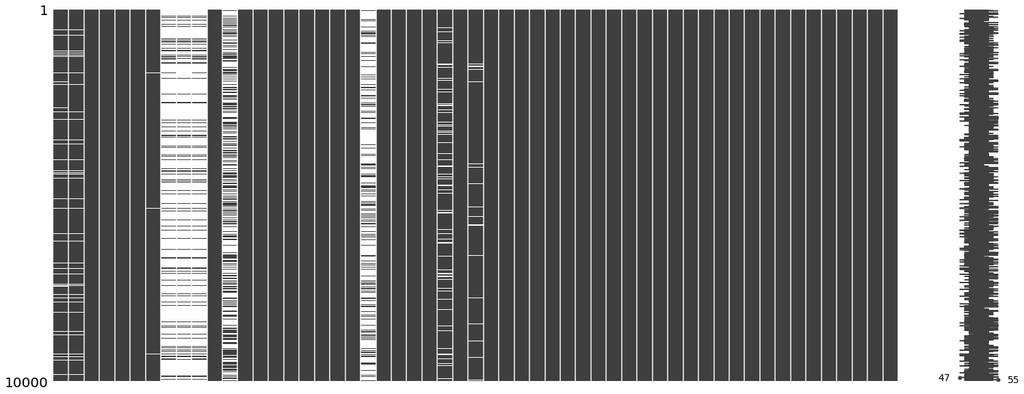

```python
import matplotlib.pyplot as plt
plt.figure(figsize=(10,10))
import missingno
missingno.matrix(df)
```

```python
df.drop(['Unnamed: 55','verification_income_joint','annual_income_joint','debt_to_income_joint','months_since_90d_late','months_since_last_delinq','num_accounts_120d_past_due'],axis=1,inplace=True)
```

```python
null_cols = ['months_since_last_credit_inquiry', 'emp_length','debt_to_income']


for col in null_cols:
    df[col] = df[col].fillna(
    df[col].dropna().mode().values[0] )
```

```python
df.drop(['state','emp_title','sub_grade'],axis=1,inplace=True)
```

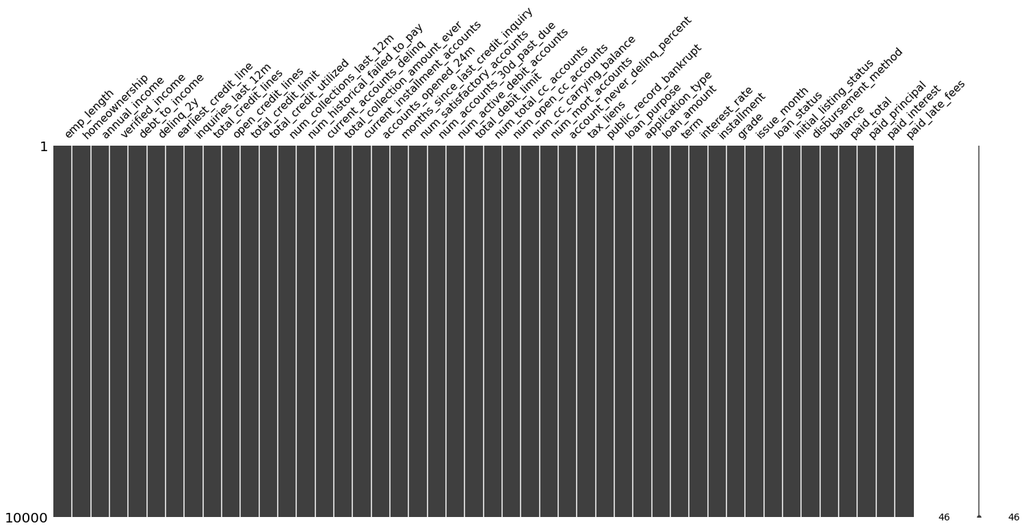

```python
plt.figure(figsize=(10,10))
missingno.matrix(df)
```

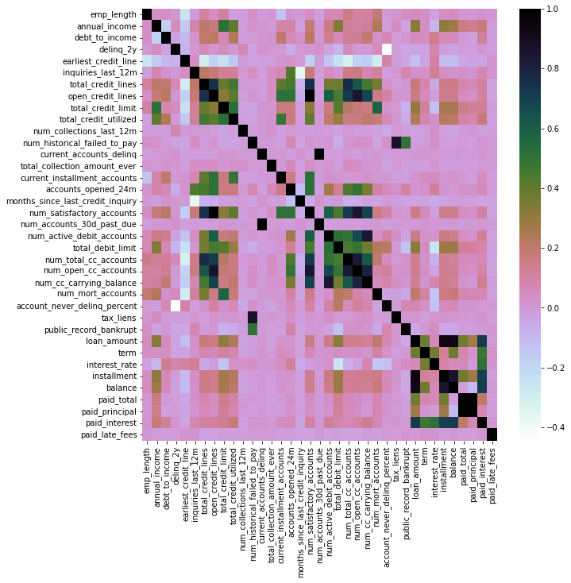

```python
plt.figure(figsize=(10,10))
sns.heatmap(df.corr() ,cmap='cubehelix_r')
```

```python
num = df.select_dtypes('number').columns.to_list()

#list of all the categoric columns
cat = df.select_dtypes('object').columns.to_list()

#numeric df
loan_num =  df[num]
#categoric df
loan_cat = df[cat]
```

# Some PLOTS

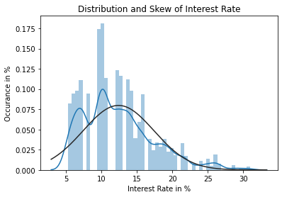

```python
def distplot(data):
    from scipy.stats import norm
    sns.distplot(data['interest_rate'], fit=norm)
    plt.title("Distribution and Skew of Interest Rate")
    plt.xlabel("Interest Rate in %")
    plt.ylabel("Occurance in %")
    plt.show()
    return
distplot(df)
```

Most models perform best when the data they deal with is normally distributed (especially linear models). But we see our target variable little right skewed but close enough to normal. The extended tail forward gives a clear sign of a positive skew in our interest rate. This means that there are much more lower values than there are high values.

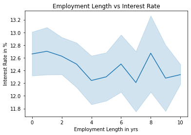

```python
def lines(data):
    sns.lineplot(x=data['emp_length'], y=data['interest_rate'])
    plt.title("Employment Length vs Interest Rate")
    plt.xlabel("Employment Length in yrs")
    plt.ylabel("Interest Rate in %")
    plt.show()
    return
lines(df)
```

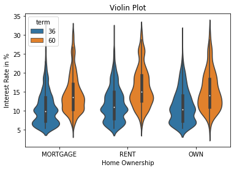

[output not shown]

```python
def violin_plot(data):
    sns.violinplot(x="homeownership", y="interest_rate", data=data, hue="term")
    plt.title("Violin Plot")
    plt.xlabel("Home Ownership")
    plt.ylabel("Interest Rate in %")
    plt.show()
    return
violin_plot(df)
```

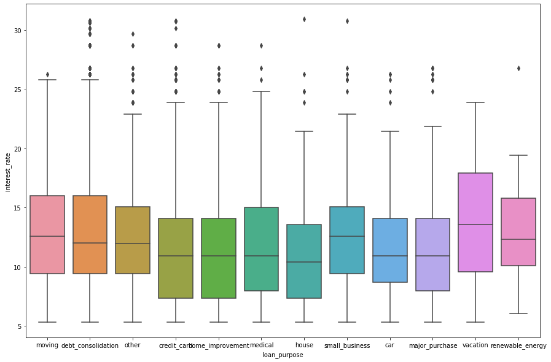

```python
plt.figure(figsize=(15,10))
sns.boxplot(x="loan_purpose", y="interest_rate", data=df)
```

The distribution of interest rate on loan purpose is kind of even and this tells customers get loan for various reasons.

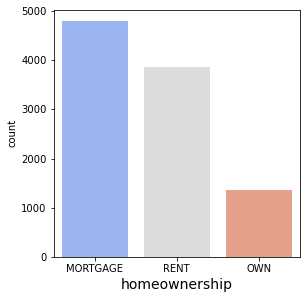

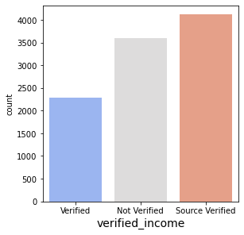

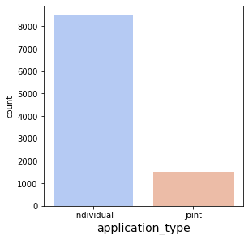

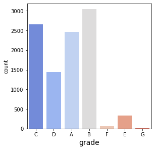

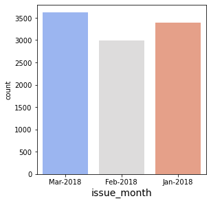

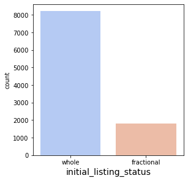

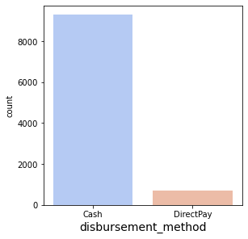

```python
for i in loan_cat.columns:
    if i != 'loan_status' and i!='loan_purpose':

        plt.figure(figsize=(15,10))
        plt.subplot(2,3,1)
        sns.countplot(x=df[str(i)] , data=df ,palette='coolwarm')
        plt.xlabel(i, fontsize=14)
```

We see different categorical variables distributed over the data on the count. We see most of the customers option for cash payment. Also the grade of interest rate is covered by A,B,C,D which are lower values. Customers try to provide most details which leads them to get lower interest rate.

#### Removing Outliers

```python
def remove_outliers(df, x):
    # Set Limits
    q10, q90 = np.percentile(df[x], 10), np.percentile(df[x], 90)
    iqr = q90 - q10
    cut_off = iqr * 1.5
    lower, upper = q10-cut_off ,  q90 + cut_off
    df[df[x]>upper] = upper
    df[df[x]<lower] = lower
    #print('Outliers of "{}" are removed\n'.format(x))
    return df
```

```python
out=loan_num
for item in out.columns:
    outlier_df= remove_outliers(out, item)
```

[output not shown]

[output cut: 1125 more lines]

[output not shown]

```python
new_df=pd.concat([outlier_df,loan_cat],axis=1)
```

```python
new_df
```

|  | emp_length | annual_income | debt_to_income | delinq_2y | earliest_credit_line | inquiries_last_12m | total_credit_lines | open_credit_lines | total_credit_limit | total_credit_utilized | ... | paid_late_fees | homeownership | verified_income | loan_purpose | application_type | grade | issue_month | loan_status | initial_listing_status | disbursement_method |
| --- | --- | --- | --- | --- | --- | --- | --- | --- | --- | --- | --- | --- | --- | --- | --- | --- | --- | --- | --- | --- | --- |
| 0 | 0.0 | 0.0 | 0.00 | 0.0 | 0.0 | 0.0 | 0.0 | 0.0 | 0.0 | 0.0 | ... | 0.0 | MORTGAGE | Verified | moving | individual | C | Mar-2018 | Current | whole | Cash |
| 1 | 10.0 | 40000.0 | 5.04 | 0.0 | 1996.0 | 1.0 | 30.0 | 14.0 | 28800.0 | 4321.0 | ... | 0.0 | RENT | Not Verified | debt_consolidation | individual | C | Feb-2018 | Current | whole | Cash |
| 2 | 0.0 | 0.0 | 0.00 | 0.0 | 0.0 | 0.0 | 0.0 | 0.0 | 0.0 | 0.0 | ... | 0.0 | RENT | Source Verified | other | individual | D | Feb-2018 | Current | fractional | Cash |
| 3 | 0.0 | 0.0 | 0.00 | 0.0 | 0.0 | 0.0 | 0.0 | 0.0 | 0.0 | 0.0 | ... | 0.0 | RENT | Not Verified | debt_consolidation | individual | A | Jan-2018 | Current | whole | Cash |
| 4 | 10.0 | 35000.0 | 57.96 | 0.0 | 2008.0 | 7.0 | 22.0 | 16.0 | 69839.0 | 52722.0 | ... | 0.0 | RENT | Verified | credit_card | joint | C | Mar-2018 | Current | whole | Cash |
| ... | ... | ... | ... | ... | ... | ... | ... | ... | ... | ... | ... | ... | ... | ... | ... | ... | ... | ... | ... | ... | ... |
| 9995 | 10.0 | 108000.0 | 22.28 | 0.0 | 2008.0 | 5.0 | 44.0 | 13.0 | 199195.0 | 77963.0 | ... | 0.0 | RENT | Source Verified | other | individual | A | Jan-2018 | Current | whole | Cash |
| 9996 | 0.0 | 0.0 | 0.00 | 0.0 | 0.0 | 0.0 | 0.0 | 0.0 | 0.0 | 0.0 | ... | 0.0 | MORTGAGE | Verified | debt_consolidation | individual | D | Feb-2018 | Current | whole | Cash |
| 9997 | 10.0 | 67000.0 | 45.26 | 2.0 | 2004.0 | 0.0 | 18.0 | 11.0 | 346402.0 | 95421.0 | ... | 0.0 | MORTGAGE | Verified | debt_consolidation | joint | E | Feb-2018 | Current | fractional | Cash |
| 9998 | 1.0 | 80000.0 | 11.99 | 0.0 | 1999.0 | 1.0 | 38.0 | 15.0 | 294475.0 | 27641.0 | ... | 0.0 | MORTGAGE | Source Verified | other | individual | A | Feb-2018 | Current | whole | Cash |
| 9999 | 3.0 | 66000.0 | 20.82 | 0.0 | 2005.0 | 0.0 | 15.0 | 11.0 | 91887.0 | 53413.0 | ... | 0.0 | RENT | Not Verified | credit_card | individual | B | Feb-2018 | Current | whole | Cash |

10000 rows × 46 columns

```python
num = new_df.select_dtypes('number').columns.to_list()

cat = new_df.select_dtypes('object').columns.to_list()

#numeric df
loan_num =  new_df[num]
#categoric df
loan_cat = new_df[cat]
```

#### Scaling Data

```python
q=[]
for i in loan_num.columns:
    q.append(i)
from sklearn.preprocessing import MinMaxScaler
scaler = MinMaxScaler()
scaled = pd.DataFrame(scaler.fit_transform(loan_num),columns=q)
```

```python
df2=pd.concat([scaled,loan_cat],axis=1)
```

```python
tdf=pd.get_dummies(df2,drop_first=True)
```

#### PCA

```python
def dimensionality_reduction(X):
    from sklearn.decomposition import PCA
    pca = PCA(n_components=25)
    X = pca.fit_transform(X_train)
    return X
fdf=pd.DataFrame(dimensionality_reduction(tdf))
```

```python
np.cumsum(pca.explained_variance_ratio_)
```

[output not shown]

### Linear Regression

```python
X = tdf.drop(columns='interest_rate').iloc[:,:25]
y = tdf['interest_rate']
```

```python
from sklearn import metrics
from sklearn.linear_model import LinearRegression, RidgeCV
from sklearn.metrics import mean_squared_error
from sklearn.model_selection import train_test_split
```

```python
X_train,X_test,y_train,y_test = train_test_split(X,y,test_size=0.2,random_state =42)
lr=LinearRegression()
lr.fit(X_train,y_train)
```

```
LinearRegression()
```

```python
y_pred = lr.predict(X_test)
y_pred.shape
```

```
(2000,)
```

```python
print('Mean Absolute Error:', metrics.mean_absolute_error(y_test, y_pred))
print('Mean Squared Error:', metrics.mean_squared_error(y_test, y_pred))
print('Root Mean Squared Error:', np.sqrt(metrics.mean_squared_error(y_test, y_pred)))
```

```
Mean Absolute Error: 0.09367581047876067
Mean Squared Error: 0.018221090515296127
Root Mean Squared Error: 0.13498551965042815
```

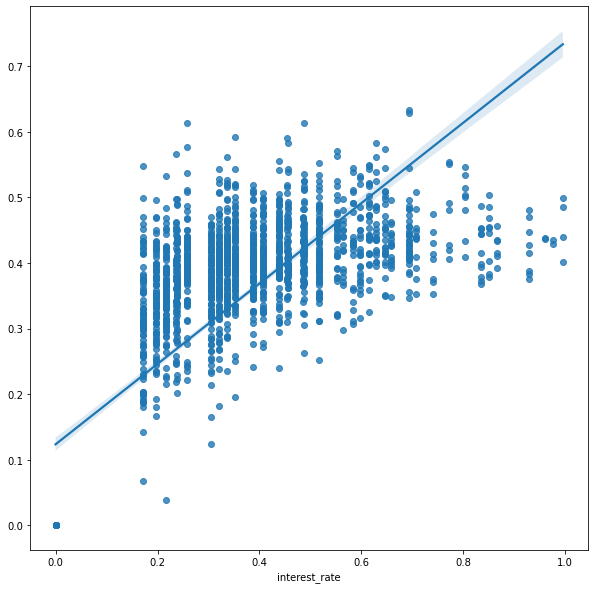

```python
plt.figure(figsize=(10,10))
sns.regplot(x=y_test, y=y_pred)
```

### Ridge Regression

```python
from sklearn.model_selection import RepeatedKFold
from sklearn.linear_model import Ridge
model = Ridge(alpha=0.51)
model.fit(X_train, y_train)
y_pred=model.predict(X_test)
```

```python
print('Mean Absolute Error:', metrics.mean_absolute_error(y_test, y_pred))
print('Mean Squared Error:', metrics.mean_squared_error(y_test, y_pred))
print('Root Mean Squared Error:', np.sqrt(metrics.mean_squared_error(y_test, y_pred)))
```

```
Mean Absolute Error: 0.09357864426077961
Mean Squared Error: 0.018183549987922275
Root Mean Squared Error: 0.13484639404864437
```

## Assumptions

#### The assumtpions made under PCA is that it assumes linearity in data which is present due to regression of the target variables. Another assumption is that the principal component with high variance must be paid attention and the PCs with lower variance are disregarded as noise. Another assumption about outliers in the dataset is minimum which is taken care of in the EDA.

#### The linear dependcy data is assumed in forming regression model.

## What could I have done better?

#### The data we have is large but we could have had a larger dataset which had least skewdness and comes from a normal distribution. We know from Central Limit Theorem that if we increase the data enough we approach towards a standard normal. More normalised data will yield better results. I could have cleaned data further and removed extreme values in different features. The number of features were too much which increased the dimenionality. There was room for hyper parameter tuning as paramters are not tuned and could have been set up for better results using techniques like grid search. I could have ensemble methods like bagging/boosting for better results.